# Tarea 4

Shanthal Chavarría

8/26/2020

# Pregunta 1

En este ejercicio vamos a usar la tabla de datos SpotifyTop2018 40 V2.csv, que contiene una lista de 40 de las canciones más reproducidas en Spotify en el año 2018. Los datos incluyen una serie de características importantes del audio de cada canción. La tabla contiene 40 filas y 11 columnas, las cuales se explican a continuación. danceability: Describe qué tan apta para bailar es la canción denergy: Representa una medida de intensidad y actividad. dloudness: Sonoridad general de la pista en decibelios. dspeechiness: Detecta la presencia de palabras en la canción. dacousticness: Indica qué tan acústica es la canción. dinstrumentalness: Indica si la canción contiene o no voces. dliveness: Detecta la presencia de público en la grabación. dvalence: Describe la positividad musical transmitida por la canción. dtempo: Es el tempo estimado general de una pista en beats por minuto. dduration ms: Es la duración de la canción en milisegundos. dtime signature: Especifica cuántos beats hay en cada barra o medida. Nota: Todas son variables numéricas y no tienen NAs. Realice lo siguiente:

```r
library(readr)

SpotifyTop2018_40_V2 <- read.table("Datos de la Presentación y para la Tarea/SpotifyTop2018_40_V2.csv", row.names = 1, header = TRUE, sep = ",", dec = ".")
```

## a) Calcule el resumen numérico, interprete los resultados para dos variables.

```r
summary(SpotifyTop2018_40_V2)
```

```
  danceability        energy          loudness       speechiness
 Min.   :0.2580   Min.   :0.3910   Min.   :-9.211   Min.   :0.02320
 1st Qu.:0.6805   1st Qu.:0.5643   1st Qu.:-7.077   1st Qu.:0.04955
 Median :0.7500   Median :0.6590   Median :-5.930   Median :0.10550
 Mean   :0.7192   Mean   :0.6619   Mean   :-5.846   Mean   :0.12129
 3rd Qu.:0.8175   3rd Qu.:0.7725   3rd Qu.:-4.624   3rd Qu.:0.14450
 Max.   :0.9220   Max.   :0.9090   Max.   :-3.093   Max.   :0.51600
  acousticness      instrumentalness       liveness          valence
 Min.   :0.000282   Min.   :0.000e+00   Min.   :0.02150   Min.   :0.0967
 1st Qu.:0.030800   1st Qu.:0.000e+00   1st Qu.:0.09527   1st Qu.:0.2875
 Median :0.121500   Median :3.220e-06   Median :0.11200   Median :0.4375
 Mean   :0.184621   Mean   :3.695e-03   Mean   :0.17713   Mean   :0.4679
 3rd Qu.:0.227500   3rd Qu.:4.325e-05   3rd Qu.:0.29475   3rd Qu.:0.6332
 Max.   :0.847000   Max.   :1.340e-01   Max.   :0.55200   Max.   :0.9310
     tempo         duration_ms     time_signature
 Min.   : 77.17   Min.   : 95467   Min.   :3.00
 1st Qu.: 95.04   1st Qu.:189856   1st Qu.:4.00
 Median :122.53   Median :212904   Median :4.00
 Mean   :122.11   Mean   :205646   Mean   :3.95
 3rd Qu.:140.59   3rd Qu.:226983   3rd Qu.:4.00
 Max.   :191.70   Max.   :268867   Max.   :4.00
```

## b) Realice el test de normalidad para una variable e interprete el resultado

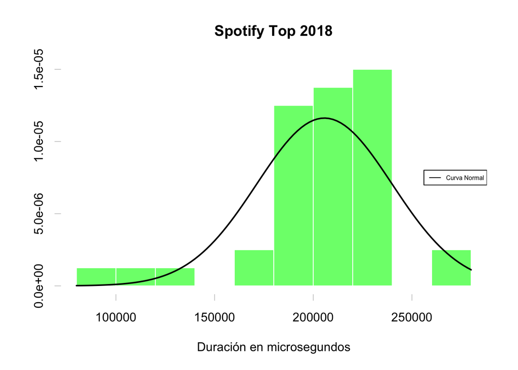

```r
promedio <- mean(SpotifyTop2018_40_V2$duration_ms)
desviacion <- sd(SpotifyTop2018_40_V2$duration_ms)
values <- dnorm( SpotifyTop2018_40_V2$duration_ms, mean = promedio, sd = desviacion)
values <- c(values, hist(SpotifyTop2018_40_V2$duration_ms,  plot = F)$density)
hist(SpotifyTop2018_40_V2$duration_ms, col = '#00FF22AA', border=F, axes=F,
  freq = F, ylim = range(0, max(values)), ylab = '',
  main = 'Spotify Top 2018', xlab = "Duración en microsegundos")
axis(1, col=par('bg'), col.ticks='grey81', lwd.ticks=1, tck=-0.025)
axis(2, col=par('bg'), col.ticks='grey81', lwd.ticks=1, tck=-0.025)
curve(dnorm(x, mean = promedio, sd = desviacion), add=T, col='black', lwd=2)
legend('right', legend = 'Curva Normal', col = 'black', lty=1, cex=.5)
```

Según el gráfico parece que la “cola” de la distribución apunta hacia la izquierda, esto quiere decir que la mayor parte de las canciones tiene una duración relativamente larga.

## c) Realice un gráfico de dispersión e interprete dos similitudes en el gráfico.

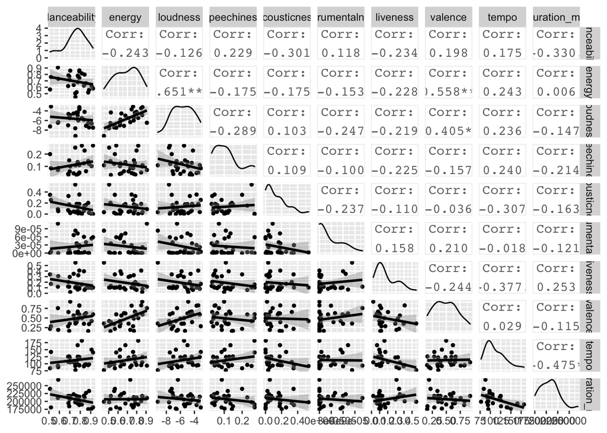

```r
eliminar_atipicos <- function(df) {
  df[] <- lapply(df, function(x) {
    if(is.numeric(x)) {
      atipicos <- boxplot(x, plot = F)$out
      x[x %in% atipicos] <- NA_real_
      return(x)
    }
    return(x)
  })
  df <- as.data.frame(df)
  na.omit(df)
}

datos = eliminar_atipicos(SpotifyTop2018_40_V2)

  #as.data.frame(scale(SpotifyTop2018_40_V2))

ggpairs(datos[,-11], lower = list(continuous = wrap("smooth", size=1)))
```

## d) Para dos variables identifique los datos atípicos, si los hay.

```r
SpotifyTop2018_40_V2[!rownames(SpotifyTop2018_40_V2) %in% rownames(datos),]
```

```
                                   danceability energy loudness speechiness
Call_Out_My_Name                          0.489  0.598   -4.929      0.0360
River_(feat._Ed_Sheeran)                  0.748  0.749   -5.916      0.5160
Perfect                                   0.599  0.448   -6.312      0.0232
Thunder                                   0.605  0.822   -4.833      0.0438
Psycho_(feat._Ty_Dolla_$ign)              0.739  0.559   -8.011      0.1170
Everybody_Dies_In_Their_Nightmares        0.734  0.570   -7.066      0.1330
                                   acousticness instrumentalness liveness
Call_Out_My_Name                        0.21800         0.00e+00   0.3500
River_(feat._Ed_Sheeran)                0.14200         0.00e+00   0.0713
Perfect                                 0.16300         0.00e+00   0.1060
Thunder                                 0.00671         1.34e-01   0.1470
Psycho_(feat._Ty_Dolla_$ign)            0.58000         0.00e+00   0.1120
Everybody_Dies_In_Their_Nightmares      0.84700         2.14e-05   0.1120
                                   valence   tempo duration_ms time_signature
Call_Out_My_Name                     0.172 134.045      228373              3
River_(feat._Ed_Sheeran)             0.659  90.090      221013              4
Perfect                              0.168  95.050      263400              3
Thunder                              0.288 167.997      187147              4
Psycho_(feat._Ty_Dolla_$ign)         0.439 140.124      221440              4
Everybody_Dies_In_Their_Nightmares   0.689 129.953       95467              4
 [ reached 'max' / getOption("max.print") -- omitted 7 rows ]
```

```r
boxplot(SpotifyTop2018_40_V2$duration_ms, plot = F)$out
```

```
[1]  95467 119133 131064
```

```r
boxplot(SpotifyTop2018_40_V2$instrumentalness, plot = F)$out
```

```
[1] 0.134 0.013
```

## e) Calcule la matriz de correlaciones, incluya alguna de las imágenes que ofrece R e interpréte dos de las correlaciones. Debe ser una interpretación dirigida a una persona que no sabe nada de estadística.

```r
library(corrplot)
library(ellipse)

matriz.correlaciones <- cor(SpotifyTop2018_40_V2)
matriz.correlaciones
```

```
                 danceability       energy    loudness speechiness acousticness
danceability       1.00000000 -0.052973197 -0.04332003  0.20739685  0.016291189
energy            -0.05297320  1.000000000  0.66563377 -0.03522523 -0.269420435
loudness          -0.04332003  0.665633766  1.00000000 -0.28162075 -0.081193798
speechiness        0.20739685 -0.035225228 -0.28162075  1.00000000  0.097140342
acousticness       0.01629119 -0.269420435 -0.08119380  0.09714034  1.000000000
instrumentalness  -0.10219848  0.159487395  0.07978047 -0.13197148 -0.150741663
                 instrumentalness    liveness     valence        tempo
danceability          -0.10219848 -0.03139211  0.47064850 -0.301067115
energy                 0.15948739 -0.08206608  0.46574186  0.005003471
loudness               0.07978047 -0.05014529  0.40227345 -0.034437816
speechiness           -0.13197148 -0.22559158  0.05961193  0.018452865
acousticness          -0.15074166 -0.15592990  0.17496739 -0.064331831
instrumentalness       1.00000000 -0.04609379 -0.13053402  0.254821754
                 duration_ms time_signature
danceability     -0.30530339    0.268821223
energy           -0.03521482    0.234110003
loudness          0.01191078   -0.032556614
speechiness      -0.14474048    0.224884152
acousticness     -0.29722638   -0.006533519
instrumentalness -0.07217052    0.040437860
 [ reached getOption("max.print") -- omitted 5 rows ]
```

[figure not shown]

```r
corrplot(matriz.correlaciones)
```

```r
plotcorr(matriz.correlaciones, col = "red")
```

[output not shown]

Según el gráfico de correlaciones, las canciones con positividad músical (valance) también son bastante bailables (danceability), enérgicas y bulliciosas. Sin embargo tienen un tempo menor y una duración más corta.

## f) Efectúe un ACP y dé una interpretación siguiendo los siguientes pasos:

```r
library(FactoMineR)
library(factoextra)

res <-PCA(SpotifyTop2018_40_V2, scale.unit=TRUE, ncp=5, graph = FALSE)
```

En el círculo de correlación determine la correlación entre las variables.

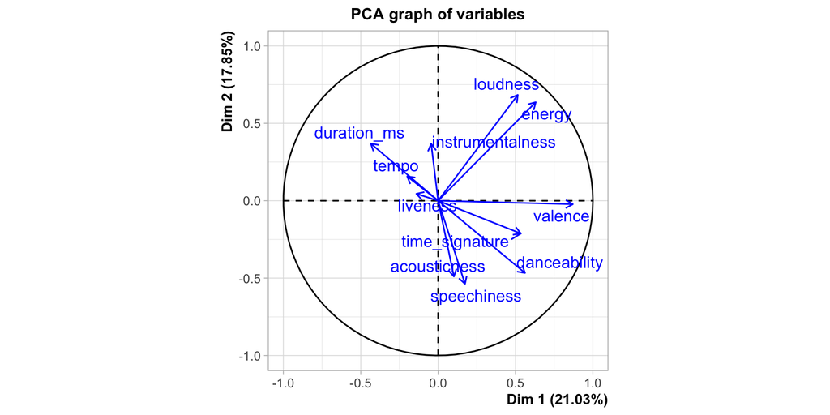

```r
plot(res, axes=c(1, 2), choix="var", col.var="blue",new.plot=TRUE)
```

Explique la formación de los clústeres basado en la sobreposición del círculo y el plano.

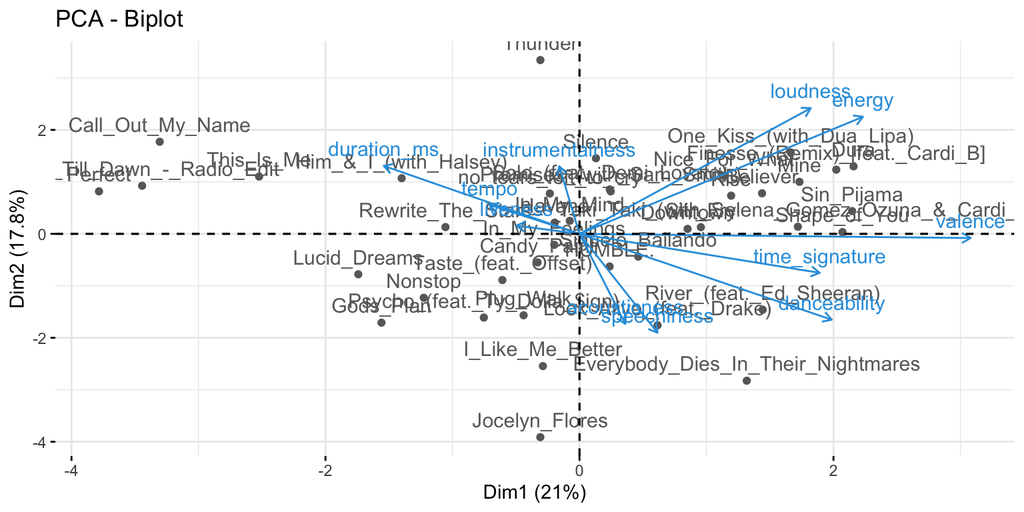

```r
fviz_pca_biplot(res,col.var = "#2E9FDF",col.ind = "#696969")
```

· En el plano de los componentes 1 y 3 interprete las canciones In My Feelings, In My Mind, Havana, Candy Paint y HUMBLE, que son mal representadas en los componentes 1 y 2.

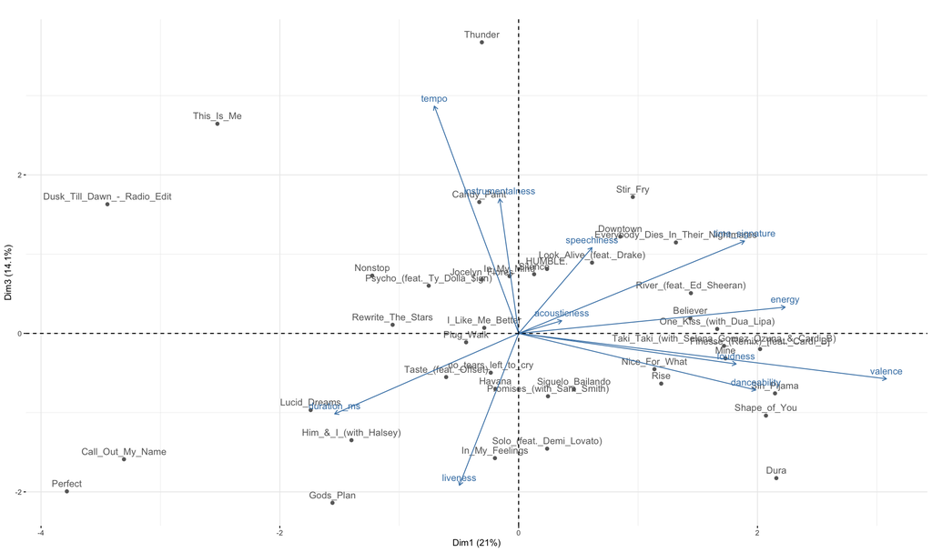

```r
knitr::include_graphics("descarga.png")
```

En los componentes 1 y 3 In My Feelings y Havanna se representan como canciones de larga duración y con público grabado. In My Mind y Humble son descritas como con canciones con más palabras, mayor compas y energía y finalmente Candy Paint es más instrumental y tiene un mayor tempo

# Pregunta 2.

En este ejercicio vamos a usar los datos TablaAffairs.csv, los cuales recopilan información sobre infidelidades en parejas casadas, como lo es la edad de la persona, años de casado y el nivel de educación.

La tabla contiene 601 filas y 9 columnas, las cuales se explican a continuación. TiempoInfiel: Medida del tiempo que pasó en la relación fuera del matrimonio. Genero: Género del individio Edad: Edad del individuo AnnosCasado: Años que lleva casado Hijos: Indica si hay hijos en el matrimonio o no. Religioso: Índice del grado de religiosidad. Entre más alto más religioso. Educación: Indice del grado de educación. Entre más alto, mayor educación. Ocupacion: Indica la categoría de ocupación de la persona. Valoracion: Valoración que da el individuo al matrimonio. Realice lo siguiente:

```r
TablaAffairs <- read.table("Datos de la Presentación y para la Tarea/TablaAffairs.csv", sep = ";", dec = ".", header = TRUE, row.names = 1)
```

## a) Calcule el resumen numérico, interprete los resultados para una variable.

```r
summary(TablaAffairs)
```

```
  TiempoInfiel       Genero               Edad        AnnosCasado
 Min.   : 0.000   Length:601         Min.   :17.50   Min.   : 0.125
 1st Qu.: 0.000   Class :character   1st Qu.:27.00   1st Qu.: 4.000
 Median : 0.000   Mode  :character   Median :32.00   Median : 7.000
 Mean   : 1.456                      Mean   :32.49   Mean   : 8.178
 3rd Qu.: 0.000                      3rd Qu.:37.00   3rd Qu.:15.000
 Max.   :12.000                      Max.   :57.00   Max.   :15.000
    Hijos             Religioso       Educacion       Ocupacion
 Length:601         Min.   :0.510   Min.   : 8.89   Min.   :1.000
 Class :character   1st Qu.:2.110   1st Qu.:14.27   1st Qu.:3.000
 Mode  :character   Median :3.200   Median :16.39   Median :5.000
                    Mean   :3.128   Mean   :16.19   Mean   :4.195
                    3rd Qu.:4.140   3rd Qu.:17.86   3rd Qu.:6.000
                    Max.   :5.490   Max.   :20.50   Max.   :7.000
  Valoracion
 Length:601
 Class :character
 Mode  :character
```

## b) Calcule la matriz de correlaciones, incluya alguna de las imágenes que ofrece R e interpréte dos de las correlaciones. Debe ser una interpretación dirigida a una persona que no sabe nada de estadística.

```r
TablaAffairsCuantit <- Filter(is.numeric,TablaAffairs)
matriz.correlaciones2 <- cor(TablaAffairsCuantit)

matriz.correlaciones2
```

```
             TiempoInfiel      Edad AnnosCasado   Religioso   Educacion
TiempoInfiel   1.00000000 0.0952372  0.18684169 -0.13750101 -0.01033040
Edad           0.09523720 1.0000000  0.77754585  0.17895211  0.13038951
AnnosCasado    0.18684169 0.7775458  1.00000000  0.20026108  0.03020485
Religioso     -0.13750101 0.1789521  0.20026108  1.00000000 -0.02142343
Educacion     -0.01033040 0.1303895  0.03020485 -0.02142343  1.00000000
Ocupacion      0.04961176 0.1664125  0.04459201 -0.02838681  0.53474365
               Ocupacion
TiempoInfiel  0.04961176
Edad          0.16641254
AnnosCasado   0.04459201
Religioso    -0.02838681
Educacion     0.53474365
Ocupacion     1.00000000
```

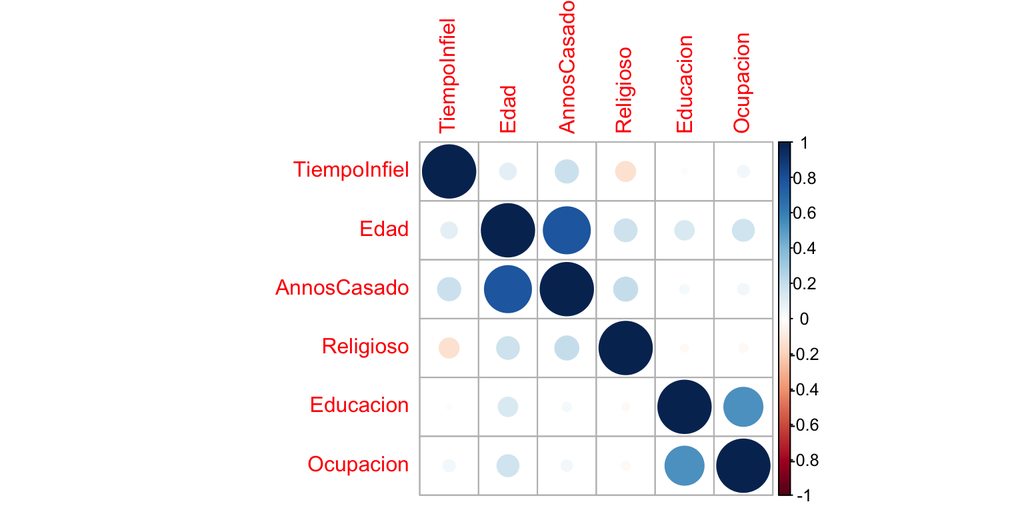

```r
corrplot(matriz.correlaciones2)
```

## c) Usando solo las variables numéricas efectué un ACP y dé una interpretación siguiendo los siguientes pasos:

1. en el plano principal encuentre 4 clústeres.

[figure not shown]

2. en el círculo de correlación determine la correlación entre las variables.

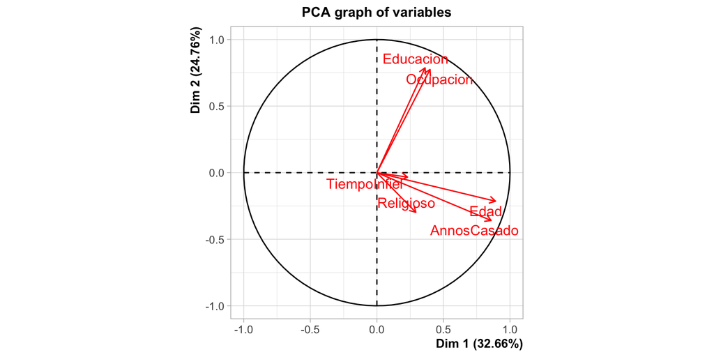

```r
modelo <- PCA(TablaAffairsCuantit, scale.unit=TRUE, ncp=5, graph = FALSE)

plot(modelo, axes=c(1, 2), choix="var", col.var="red", new.plot=TRUE)
```

Las variables de Educación y ocupación relacionan positivamente. Tiene sentido que la Edad y los Años Casados tengan una relación fuerte y positiva; aunque no estén bien representadas Religioso y Tiempo de Infidelidad se relacionan positivamente con estas también.

3. Explique la formación de los clústeres basado en la sobre-posición del círculo y el plano.

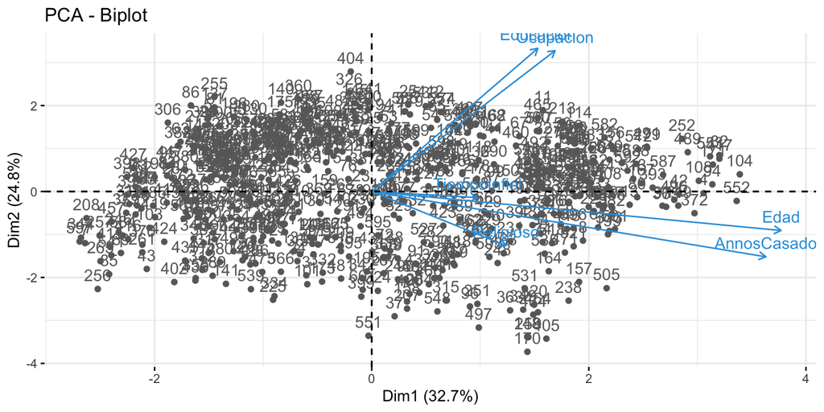

```r
fviz_pca_biplot(modelo, col.var = "#2E9FDF",col.ind = "#696969")
```

Según el gráfico anterior, parece que el mayor número de personas que cometió infidelidad lo hizo por poco tiempo, eran de edades no avanzadas, no religiosos y con pocos años casados. Su educación parece ser indiferente para este grupo, hay otro grupo con Educación y Trabajando que también concentra una cantidad importante que no se relaciona con ninguna de las demás variables.

## d) Ahora convierta las variables Género e Hijos en Código Disyuntivo Completo y repita el ACP ¿Se gana interpretabilidad al convetir Género e Hijos en Código Disyuntivo Completo?

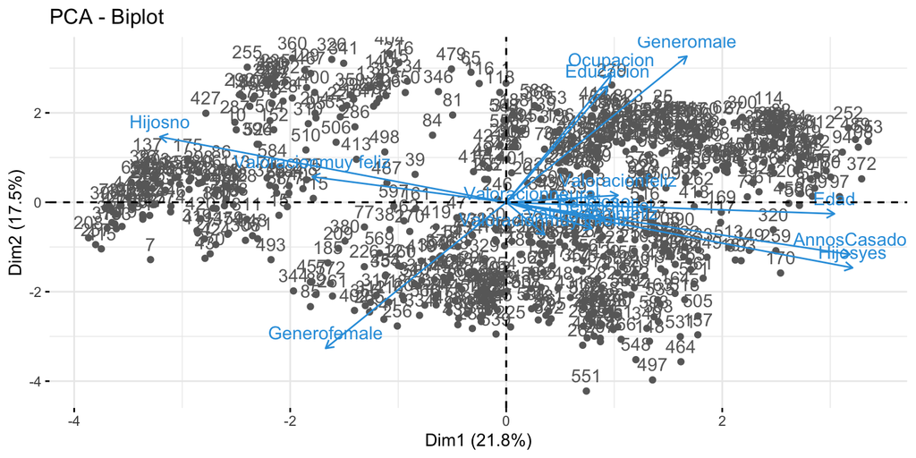

```r
library(dummies)
TablaAffairs1 <- dummy.data.frame(TablaAffairs)

modelo1 <- PCA(TablaAffairs1, scale.unit=TRUE, ncp=5, graph = FALSE)

fviz_pca_biplot(modelo1, col.var = "#2E9FDF",col.ind = "#696969")
```

Si, parece ser que las personas que se consideran felices en la relación no llevan mucho tiempo de casadas y su tiempo siendo infieles es menor, además no tienen hijos. Las personas que indicaron que se sentían infelices muestran todo lo contrario. El género parece ser independiente del tiempo de infidelidad o de si son felices.

# Pregunta 3.

En este ejercicio vamos a realizar un ACP para la tabla SAheart.csv la cual contiene variables numéricas y categóicas mezcladas. La descripción de los datos es la siguiente: Datos Tomados del libro: The Elements of Statistical Learning Data Mining, Inference, and Prediction de Trevor Hastie, Robert Tibshirani y Jerome Friedman de la Universidad de Stan- ford. .Example: South African Heart Disease: A retrospective sample of males in a heart-disease high-risk region of the Western Cape, South Africa. There are roughly two controls per case of coronary heart disease. Many of the coronary heart disease positive men have undergone blood pressure reduction treatment and other programs to reduce their risk factors after their coro- nary heart disease event. In some cases the measurements were made after these treatments. These data are taken from a larger dataset, described in Rousseauw et al, 1983, South African Medical Journal. Below is a description of the variables: sbp: systolic blood pressure (numérica) tobacco: cumulative tobacco (kg) (numérica) ldl: low densiity lipoprotein cholesterol (numérica) Adiposity: adiposity (numérica) famhist: family history of heart disease (Present, Absent) (categórica) typea: type-A behavior (numérica) Obesity: obesity (numérica) alcohol: current alcohol consumption (numérica) age: age at onset (numérica) chd: coronary heart disease (categórica) Las dos variables categóricas se explican como sigue: famhist significa que hay historia familiar de infarto y que la variable chd significa que la persona murió de enfermedad cardíaca coronaria. Realice lo siguiente:

## a) Efectué un ACP usando solo las variables numéricas y dé una interpretación siguiendo los siguientes pasos:

En el plano principal encuentre los clústeres.

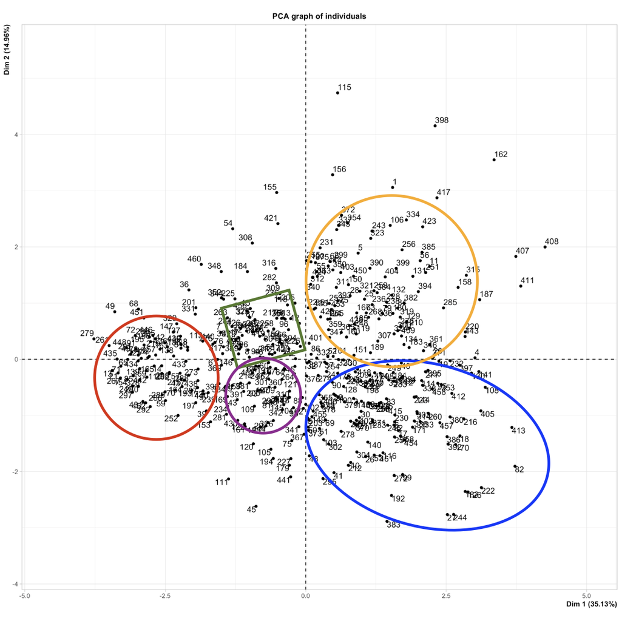

```r
SAheart <- read.table("Datos de la Presentación y para la Tarea/SAheart.csv", sep = ";", dec = ".", header = TRUE)

SAheartCuantit <- Filter(is.numeric, SAheart)

modelo <- PCA(SAheartCuantit,scale.unit=TRUE, ncp=5, graph = FALSE)

knitr::include_graphics("Captura de Pantalla 2020-08-28 a la(s) 13.38.07.png")
```

En el círculo de correlación determine la correlación entre las variables.

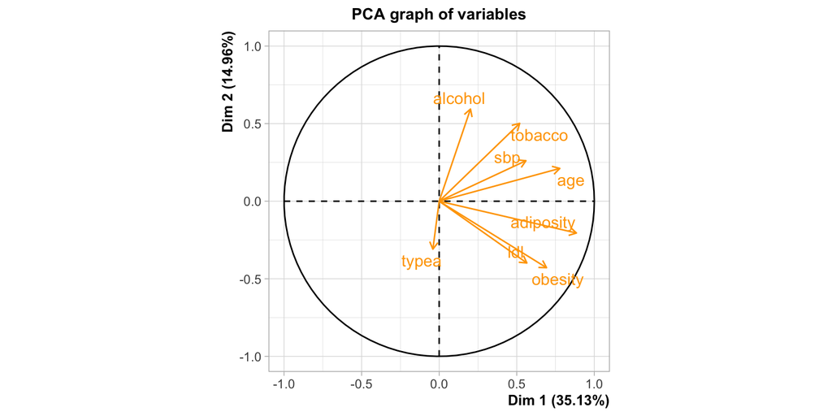

```r
plot(modelo, axes=c(1, 2), choix="var", col.var="orange", new.plot=TRUE)
```

Explique la formación de los clústeres basado en la sobre-posición del círculo y el plano.

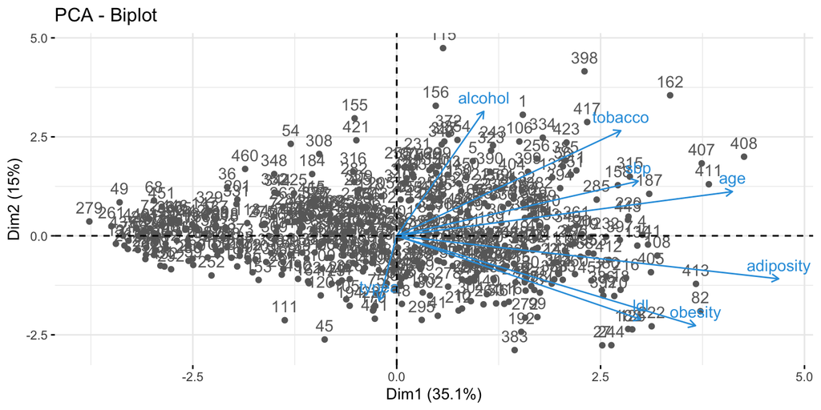

```r
fviz_pca_biplot(modelo, col.var = "#2E9FDF",col.ind = "#696969")
```

## b) Efectúe un ACP usando las variables numéricas y las variables categóricas (recuerde recodificar las categóricas usando código disyuntivo completo). Luego dé una interpretación siguiendo los siguientes pasos:

```r
SAheart1 <- dummy.data.frame(SAheart)


modelo1 <- PCA(SAheart1, scale.unit = TRUE, ncp = 5)
```

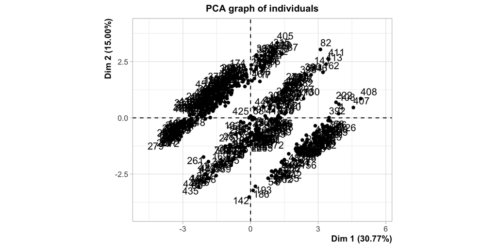

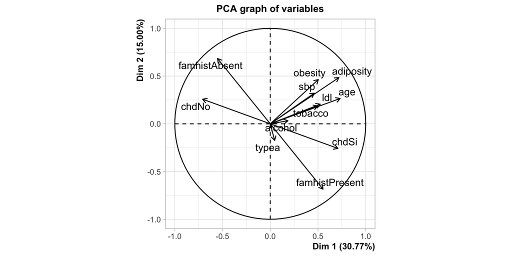

En el plano principal encuentre los clústeres.

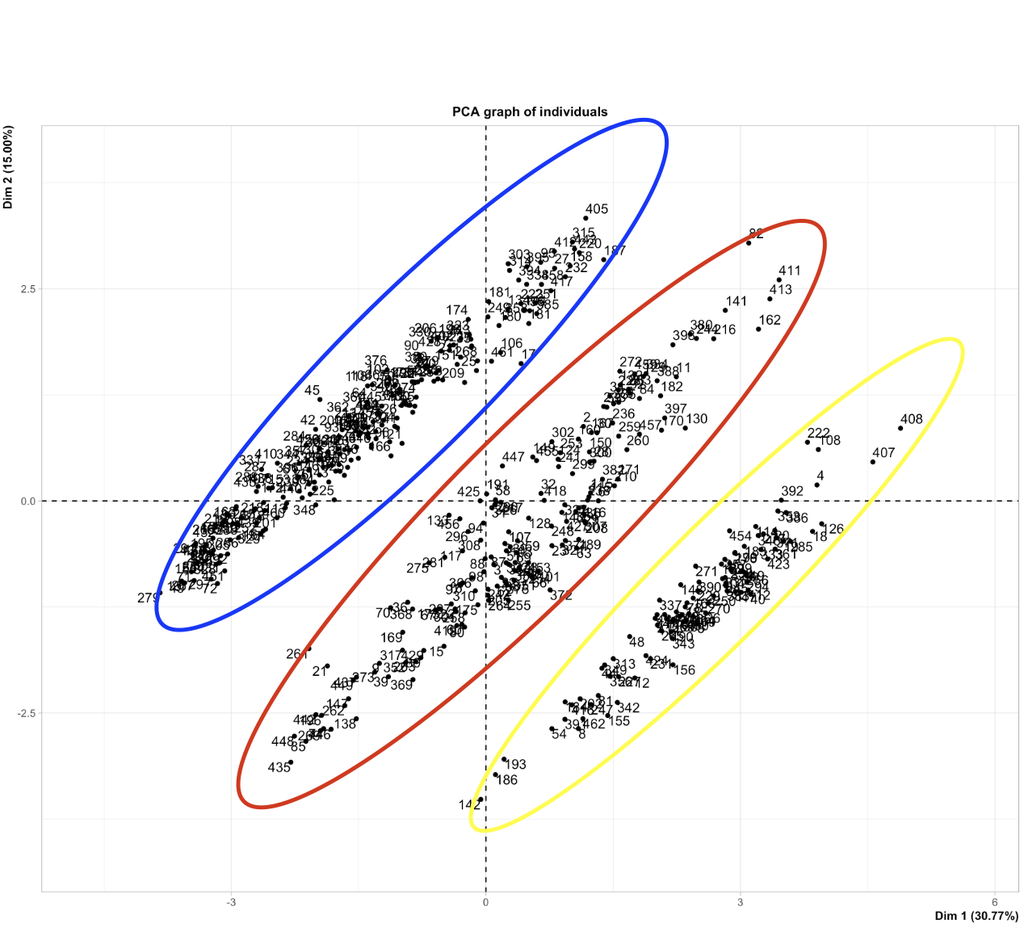

```r
knitr::include_graphics("Captura de Pantalla 2020-08-28 a la(s) 13.57.20.png")
```

En el círculo de correlación determine la correlación entre las variables.

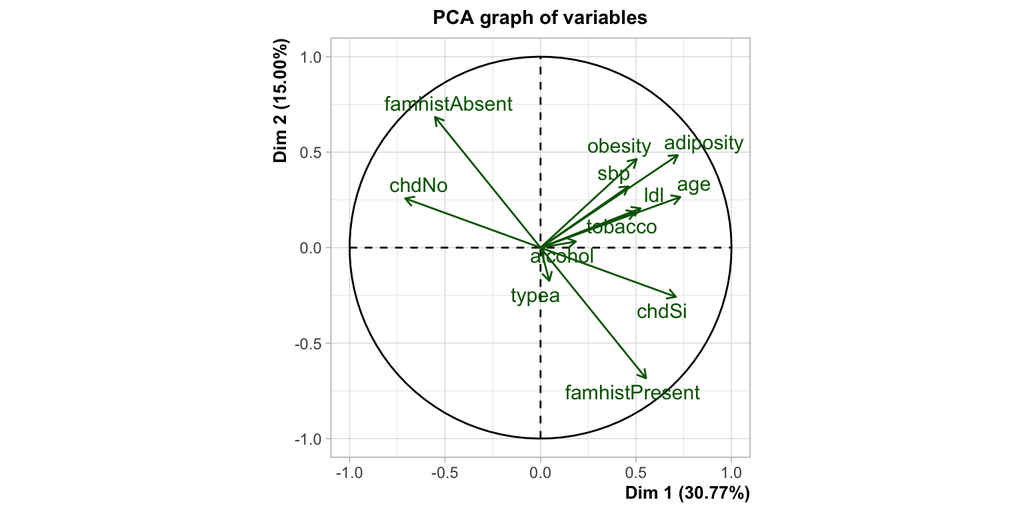

```r
plot(modelo1, axes=c(1, 2), choix="var", col.var="darkgreen", new.plot=TRUE)
```

Explique la formación de los clústeres basado en la sobre-posición del círculo y el plano.

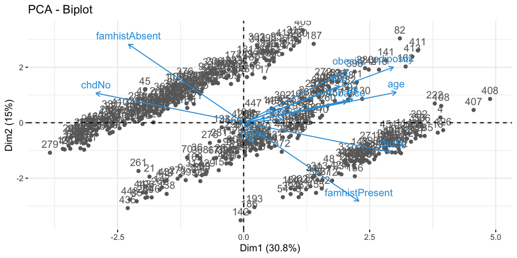

```r
fviz_pca_biplot(modelo1, col.var = "#2E9FDF",col.ind = "#696969")
```

Para el primer grupo observamos que estos no muerieron de una enfermedad cardiaca y tampoco tenían historial familiar de estas, para el segundo grupo se observa que estos son de riesgo pues presentan complicaciones en la salud y sus hábitos. Finalmente para el tercer grupo se tiene que aunque es menor que el resto estas personas murieron por enfermedades cardiacas y aunque no presentaban relación con las variables de riesgo tenían historial familiar.

Explique las diferencias de este ACP respecto al anterior (usando solo las variables numéricas. ¿Cúal le parece más interesante? ¿Por qué? El segundo me parece más interesante pues este aporta mucha más información visualmente. Explica mucho mejor la agrupación de los clusteres y se visualiza más ordenado. En el primer ACP (solo númericas), no se entendía muy bien la relación entre las variables y sus observaciones, además estas se ven mucho más agrupadas.